# Prediction Assignment

Ashley Kelly

May 1, 2018

# Introduction

One thing that people regularly do is quantify how much of a particular activity they do, but they rarely quantify how well they do it. In this project, my goal is to use data from accelerometers on the belt, forearm, arm, and dumbell of 6 participants and predict the manner in which they did the exercise. They were asked to perform barbell lifts correctly and incorrectly in 5 different ways. This is “classe” variable in the training set. I am allowed to use either of the variables to predict with. The data for this project come from this [Source](http://web.archive.org/web/20161224072740/http:/groupware.les.inf.puc-rio.br/har).

# Setting up the Exercise

First, I need to install the necessary libraries and download the data from the source.

```r
library(caret)
library(randomForest)
```

```r
if (!file.exists("pml-training.csv")) {
  trainSite <- "https://d396qusza40orc.cloudfront.net/predmachlearn/pml-training.csv"
  download.file(trainSite, destfile = "pml-training.csv")
}

if (!file.exists("pml-testing.csv")) {
  testSite <- "https://d396qusza40orc.cloudfront.net/predmachlearn/pml-testing.csv"
  download.file(testSite, destfile = "pml-testing.csv")
}

train <- read.csv("pml-training.csv")
test <- read.csv("pml-testing.csv")
```

# Setting up the data

First I will clean the data and remove the variables with missing items and get rid of columns that have non-numeric data. Since the “classe” column contains non-numeric entries, I need to extract the “classe” column from the data and add it again after I have rid the training set of the non-numeric columns.

```r
train <- train[, colSums(is.na(train)) == 0]
classe <- train$classe
train <- train[, sapply(train, is.numeric)]
train$classe <- classe
```

```r
set.seed(333)
inTrain <- createDataPartition(y = train$classe, p = 0.70, list = FALSE)

training <- train[inTrain, ]
testing <- train[-inTrain, ]
```

# Performing the Analysis

Next I will do some data prediction and modeling. First I will fit a model using the random forests method. I will use the results of the “modFit” variable as my conclusions.

```r
library(randomForest)
modFit <- randomForest(classe ~ ., ntree = 1000, data = training)
modFit
```

```
##
## Call:
##  randomForest(formula = classe ~ ., data = training, ntree = 1000)
##                Type of random forest: classification
##                      Number of trees: 1000
## No. of variables tried at each split: 7
##
##         OOB estimate of  error rate: 0%
## Confusion matrix:
##      A    B    C    D    E class.error
## A 3906    0    0    0    0           0
## B    0 2658    0    0    0           0
## C    0    0 2396    0    0           0
## D    0    0    0 2252    0           0
## E    0    0    0    0 2525           0
```

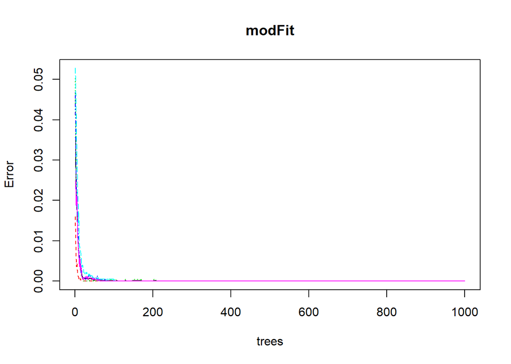

```r
plot(modFit)
```